# Implementing ANN using Tensorflow - Final Project

## Using a Convolutional Neural Network for genre Classification in music

by Group 03 - Lea Doppertin (967646) and Sven Groen (970219)

We are trying to recreate the results achieved by:

http://cs229.stanford.edu/proj2018/report/21.pdf

# Introduction

### Background

[output not shown]

### Related Work

Classical approaches towards the music genre classification problem made use of extracting hand crafted features (timbral texture, rhythmic content, etc.) which were used in combination with classical machine learning approaches like k-nearest neighbors and gaussian mixture models to classify the different genres [2].

In 2013, Humphrey, Bello, and Lecun pointed out, that progress seemed to plateau in the area of content-based music informatics and elaborated, why hand-crafted features for analysis are suboptimal and why deep learning models achieve potentially better results [5]. Since then, different deep learning approaches have been investigated, such as LSTM-classifier [6], Graph-Neural-Networks [7] or hybrid-architectures [8].

Wyse (2017) [9] showed that audio data in the form of a spectrogram can be analysed using convolutional neural networks. CNNs for music genre classification are a widely used method [10, 11]. Most of them use the Mel-Spectrogram feature in order to classify audio.

Mel-Spectrograms project normal spectrograms onto the mel scale. This leads to a visualisation in which low frequency bands are shown very precisely and higher frequency bands are shown in a compressed way [12]. Dong (2018) explained that the human ear functions in a similar fashion with higher precision on the lower frequency band. Furthermore, he was able to show that some CNN filters are similar to the spectrotemporal receptive field from the human auditory system [12].

# Dataset

For this replication, we take the audio files from the GTZAN [13] dataset. This dataset was published 2002 [3] and is a widely used dataset in the field of music genre classification [14, 15]. It is the same dataset that was also used by the authors Huang, Serafini and Pugh [4]. GTZAN consists of 1000 wav-audio files with each 30 secounds of length, which are sorted by musical genre.

The following code cell will show you the first five samples of our dataset. It contains the name of the file, the corresponding path and the genre. Since the data isn't shuffled yet, the first samples are of the same genre, namely blues in this case.

```python
import pandas as pd

df = pd.read_csv("data/csv/dataset_paths.csv")
df.head()
```

|  | filename | path | genre |
| --- | --- | --- | --- |
| 0 | blues.00000.wav | data/genres/blues/blues.00000.wav | blues |
| 1 | blues.00001.wav | data/genres/blues/blues.00001.wav | blues |
| 2 | blues.00002.wav | data/genres/blues/blues.00002.wav | blues |
| 3 | blues.00003.wav | data/genres/blues/blues.00003.wav | blues |
| 4 | blues.00004.wav | data/genres/blues/blues.00004.wav | blues |

```python
print(f"Our dataset consists of {len(df)} files. \n"
      f"There are {len(df.genre.unique())} available genres, namely {df.genre.unique()}")
```

```
Our dataset consists of 1000 files.
There are 10 available genres, namely ['blues' 'classical' 'country' 'disco' 'hiphop' 'jazz' 'metal' 'pop'
 'reggae' 'rock']
```

After running the following cell, you will be able to hear a random example with a random genre from our dataset.

```python
import librosa as lb
import IPython.display as ipd
import numpy as np

signals = []
for file in df["path"]:
    signal,sampling_rate= lb.load(file)
    signals.append(signal)
ipd.Audio(np.random.choice(signals), rate=sampling_rate)
```

[interactive chart not shown]

The sampling rate is equal across all audio files. For our dataset it is 22050.

| *Table 2: "Datasets for MGC, ordered by year of publication, specifying the size of the dataset, the number of classes or labels and the features each dataset provides." Ramírez and Julia Flores (2019… |
| --- |

| *Figure 1: "Annual numbers of published works in MGR with experimental components, divided into ones that use and do no use GTZAN." Sturm (2013) p.12 [15]* |
| --- |

To achieve a comparable result we used the GTZAN dataset an apply the same preprocessing steps described in the paper we replicate [4] (see preprocessing for detailed information).

# Concept

### Preprocessing

In general, we aim to follow the same preprocessing steps as the authors [4].

To do this, we first extract four randomly selected 2-second windows from each audio file. Therefore, we get 400 2-second samples for each genre, that is 4000 samples in total, evenly distributed in terms of genre.

To get the duration of each signal in seconds we need to devide it by the sampling rate:

s = signal

len(s)= length of signal s

sr = sampling rate of s

d = duration in seconds

$\frac{len(s)}{sr} = d$

$\Leftrightarrow len(s) = d * sr$

```python
len_signal = 2 * sampling_rate
print("To receive two-second random clips from our audio signal, we have to look at {} continous entries in our raw numpy signal.".format(len_signal))
```

```
To receive two-second random clips from our audio signal, we have to look at 44100 continous entries in our raw numpy signal.
```

To achieve this we pick one random starting index and make sure it can maximally be at 28 seconds. We then return the signal from that point to the point plus two seconds and do this four times for each audio file.

```python
# get a random starting point in the 30 sec. clip
def get_rand_sample(signal,duration,sr=22050):
    ''' samples a random part of a signal

    Parameters:
        signal (np.array): the signal from which a random sample should be drawn
        duration (int): how long the sample should be (in seconds)

    returns:
        np.array:  random part of signal of length duration (in seconds)

    '''
    len_signal=duration * sr
    rand_index = np.random.randint(len(signal)-len_signal+1,size=1)[0]

    return signal[rand_index: rand_index+len_signal]
example = get_rand_sample(signals[np.random.randint(len(signals))],2,sr=sampling_rate)
assert(len(example)/sampling_rate==2.0)
ipd.Audio(example, rate=sampling_rate)
```

[interactive chart not shown]

In the next step, we transform our samples to so-called Mel-Spectrograms. Spectrograms are simply-speaking plots visualizing sound. Mel-Spectrograms are spectrograms that are "mel-scaled", so that the mel-scale is on its y-axis. The mel-scale results from a transformation of the frequency scale, such that it resembles the frequency band that humans can perceive.

To get the Mel-Spectogram we use librosas [melspectrogram()](https://librosa.github.io/librosa/generated/librosa.feature.melspectrogram.html) method.

In terms of parameters the authors said that they chose the following parameters:

> "64 mel-bins and a window length of 512 samples with an overlap of 50% between windows. Based on previous academic success with such transformations, we then move to log-scaling using the formula $log(X^2)"$.

Huang, Serafini and Pugh (2018) p.2 [4]

We use the exact same parameters when converting our samples to Mel-Spectrograms. After running the following code cells you will be able to see two versions of a random example of a two-seconds Mel-Spectrogram.

```python
import matplotlib.pyplot as plt
from librosa import display

def get_rand_sample(signal,duration, sr=22050):
    ''' samples a random part of a signal
    Parameters:
        signal (np.array): the signal from which a random sample should be drawn
        duration (int): how long the sample should be (in seconds)

    returns:
        np.array:  random part of signal of length duration (in seconds)
    '''
    len_signal=duration * sr
    rand_index = np.random.randint(len(signal)-len_signal+1, size=1)[0]

    return signal[rand_index: rand_index+len_signal]
```

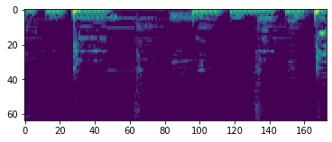

```python
example = get_rand_sample(signals[np.random.randint(len(signals))], 2, sr=sampling_rate)

# fix parameters
N_MELS = 64
SR = sampling_rate
N_FFT = 512 # window length
HOP_LENGTH = N_FFT // 2 # "50% overlap between the windows"

# convert to log decibel
mel_log = lambda x: lb.power_to_db(x**2)

mel = lb.feature.melspectrogram(example, sr=SR, n_fft=N_FFT, hop_length=HOP_LENGTH, n_mels=N_MELS)

plt.imshow(mel_log(mel))
```

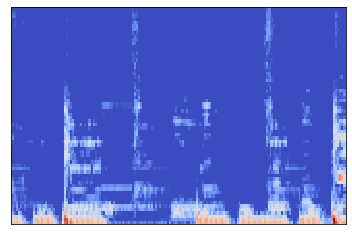

```python
lb.display.specshow(mel_log(mel))
```

The first version is the one that the authors [4] use, whereas the second one is another version of a Mel-Spectrogram that could potentially be used for classification.

Compared to each other, you might notice that they look quite similar, even though their colour schemes are very different from each one another and the first spectrogram has an axis compared to the second. However, the frequency pattern in the second spectrogram pictures the same frequency distribution, but is depicted upside down. Still, training and testing with this reversed mapping should not be a feature that could alter the CNN's performance in comparison with using only the first (not inversed) spectrogram. Although, three other different features, namely colour scheme, axis and scale, could have an influence, as they add or reduce information in each sample.

Eventually, we decided to use the first version of spectrograms as input for our model. The reason is that, even if using the second version might improve our results, we want our results to be comparable to the authors', thus the input to our model must be the same.

### Model Architecture

As already mentioned, the model we use is a Convolutional Neural Network (CNN). As it has many layers and regularizations, we suggest that you take a direct look at our architecture, which you can see in the following code cell.

In general, we try to copy the architecture of [4]. However, we notice that using all layers and especially all dropout-layers, training does not seem to occur (left out layers are commented).

```python
def cnn(input_shape, num_genres):
    inputs = tf.keras.layers.Input(shape=input_shape)

    # 1st Conv-Pool-layers
    x = tf.keras.layers.Conv2D(filters=64,
                               kernel_size=(4,4),
                               activation=tf.keras.activations.relu)(inputs)
    x = tf.keras.layers.BatchNormalization()(x)
    x = tf.keras.layers.MaxPool2D(pool_size=(2,4))(x)

    # 2nd Conv-Pool-layers
    x = tf.keras.layers.Conv2D(filters=64,
                               kernel_size=(3,5),
                               activation=tf.keras.activations.relu,
                               kernel_regularizer=tf.keras.regularizers.l2(0.04))(x)
    x = tf.keras.layers.MaxPool2D(pool_size=(2,2))(x)
#     x = tf.keras.layers.Dropout(0.2)(x) --> this layer was included in Huang et al.'s implementation

    # 3rd Conv-Pool-layers
    x = tf.keras.layers.Conv2D(filters=64,
                               kernel_size=(2,2),
                               activation=tf.keras.activations.relu)(x)
    x = tf.keras.layers.BatchNormalization()(x)
    x = tf.keras.layers.MaxPool2D(pool_size=(2,2))(x)
#     x = tf.keras.layers.Dropout(0.2)(x) --> this layer was included in Huang et al.'s implementation

    # Flatten before feeding into dense layers
    x = tf.keras.layers.Flatten()(x)

    # Dense layers
    x = tf.keras.layers.Dense(64,activation=tf.keras.activations.relu, kernel_regularizer=tf.keras.regularizers.l2(0.04))(x)
#     x = tf.keras.layers.Dropout(0.5)(x) --> this layer was included in Huang et al.'s implementation
    x = tf.keras.layers.Dense(32,activation=tf.keras.activations.relu, kernel_regularizer=tf.keras.regularizers.l2(0.04))(x)

    # output layer
    output = tf.keras.layers.Dense(num_genres, activation=tf.keras.activations.softmax)(x)

    cnn_model = tf.keras.Model(inputs=inputs, outputs=output)
    return cnn_model
```

Concerning the hyperparameters, we use a batchsize of 32, an adam optimizer and a categorical cross-entropy loss. We train for 30 epochs in total, which takes approximately 5 hours. Additionally, we chose to use a relatively small learning rate of 0.0005 to guarantee convergence.

### Training and Testing

During training we observed similar overfitting behaviour like the others. Adding L2 Regularization helped decreasing overfitting at the start of the training progress, while the whole training progress takes longer.

Adding dropout-layers like Huang, Serafini and Pugh (2018) resulted in no learning (validation accuracy of ~10%) even after 70 epochs. This overfitting does also indicates that the data might be fitted better with a simpler model.

In terms of overfitting the Huang et al. report that:

> "(...) all four of our models struggle with over-fitting. We spent the most time trying to mitigate this issue on the CNN. To do so, we introduced three methods. We played around with a combination of batch normalization, dropout layers, and L2 regularization. We found some difficulty in using this, as allowing the model to over-fit actually increased our accuracy. While we could bring the training accuracy and the test accuracy to within .05 of each other, this would result in poor model performance. Thus we accepted our over-fitting issue."

We share this experience with the authors and also accepted overfitting, since dropout-layers or increasing the regularization leads to no learning at all instead of reducing overfitting.

[output not shown]

[output not shown]

# Evaluation and Discussion

[output not shown]

# Conclusion

To conclude, we have been able to reproduce the results of [4] to some extend. We observed similar training behaviour and similar genre classification patterns. Although our model's performance has not been as good as Huang et al.'s, our results suggest that further training might lead to a better performance that is more similar to Huang et al.'s.

# References

[1] Bello, J. P. (2016). Music Information Retrieval [Powerpoint slides]. Retrieved from http://www.nyu.edu/classes/bello/MIR_files/1-Introduction.pdf

[2] Tzanetakis, G. & Cook, P. (2002). Musical Genre Classification of Audio Signals. IEEE Transactions on Speech and Audio Processing. 10. 293 - 302. 10.1109/TSA.2002.800560. Retrieved from https://www.researchgate.net/publication/3333877_Musical_Genre_Classification_of_Audio_Signals

[3] Ramírez C., Julia Flores M.. (2019). Machine learning for music genre: multifaceted review and experimentation with audioset. Journal of Intelligent Information Systems. 1-31. 10.1007/s10844-019-00582-9. Retrieved from https://arxiv.org/pdf/1911.12618.pdf

[4] Huang, D. A., Serafini, A. A., & Pugh, E. J. (2018). Music Genre Classification. Retrieved from http://cs229.stanford.edu/proj2018/report/21.pdf

[5] Humphrey, E. J., Bello, J. P., & Lecun, Y. (2013). Feature learning and deep architectures: New directions for music informatics. Journal of Intelligent Information Systems, 41(3), 461-481. https://doi.org/10.1007/s10844-013-0248-5

[6] Wong, K. & Tang, C. & Chui, K. & Yu, Y. & Zeng, Z. (2018). Music genre classification using a hierarchical long short term memory (LSTM) model. 7. 10.1117/12.2501763. Retrieved from http://www.cs.cuhk.hk/~khwong/p186_acm_00_main_lstm_music_rev5.pdf

[7] Dokania, S. & Singh, V. (2019). Graph Representation learning for Audio & Music genre Classification. Retrieved from https://arxiv.org/pdf/1910.11117.pdf

[8] Feng, L. & Liu, S. & Yao, J. (2017). Music Genre Classification with Paralleling Recurrent Convolutional Neural Network. Retrieved from https://arxiv.org/pdf/1712.08370.pdf

[9] Wyse, L. (2017). Audio Spectrogram Representations for Processing with Convolutional Neural Networks. Retrieved from https://arxiv.org/pdf/1706.09559.pdf

[10] Liu, C. & Feng, L. & Liu, G. & Wang, H. & Liu, S. (2019). Bottom-up Broadcast Neural Network For Music Genre Classification. Retrieved from https://arxiv.org/pdf/1901.08928.pdf

[11] Oramas, S., Barbieri, F., Nieto, O., & Serra, X. (2018). Multimodal Deep Learning for Music Genre Classification. Transactions of the International Society for Music Information Retrieval, 1(1), 4–21. DOI: http://doi.org/10.5334/tismir.10

[12] Dong, M. (2018). Convolutional Neural Network Achieves Human-level Accuracy in Music Genre Classification. Retrieved from https://arxiv.org/pdf/1802.09697.pdf

[13] Leben, J. (2015). GTZAN Genre Collection. Retrieved April 14, 2020, from http://marsyas.info/downloads/datasets.html

[14] Längkvist, M. & Karlsson, L. & Loutfi, A.. (2014). A Review of Unsupervised Feature Learning and Deep Learning for Time-Series Modeling. Pattern Recognition Letters. 42. 10.1016/j.patrec.2014.01.008. Retrieved from https://romisatriawahono.net/lecture/rm/survey/machine%20learning/Langkvist%20-%20Deep%20Learning%20for%20Time%20Series%20Modeling%20-%202014.pdf

[15] Sturm, B. (2013). The GTZAN dataset: Its contents, its faults, their effects on evaluation, and its future use. Retreived from https://arxiv.org/pdf/1306.1461.pdf